# Preliminary Demand vs Allocation

Draft for NCI / Pawsey data-validation discussion

```r
library(tidyverse)
library(readxl)
library(scales)
library(knitr)

# Main annual demand/allocation table
demand_raw <- read_excel(
  file.path(
    "assets",
    "data",
    "data clean",
    "demand_allocation_all_years_v2.xlsx"
  ),
  sheet = "demand_allocation"
)

# Conversion workbook used as the reference for current rules
conversion_rules_raw <- read_excel(
  file.path(
    "assets",
    "progress",
    "Yearly Conversion.xlsx"
  ),
  sheet = "Analysis 4"
)

# Analysis 4 uses blank cells for repeated years
conversion_rules <- conversion_rules_raw %>%
  fill(Year)

all_periods <- demand_raw$period
```

## Purpose

This is a **preliminary working conversion for discussion**, not a final validated historical series.

For tomorrow’s discussion, the aim is to have a complete year-by-year view rather than leave large gaps. Where the exact resource split is available, the system-specific conversion is used. Where it is not available, a clearly labelled **closest available assumption** is used to create a provisional **CPU-equivalent** series.

The objectives are to:

1. confirm that the historical demand and allocation figures have been interpreted correctly;
2. confirm the current system-specific conversion rules;
3. show a complete preliminary demand-versus-allocation trend for 2013/14–2025/26; and
4. identify which years rely on stronger or weaker assumptions before the final forecast is built.

## Source data collected so far

```r
demand_raw %>%
  select(
    period,
    demand,
    demand_uom,
    allocation,
    allocation_uom,
    source_status,
    reason,
    source_link
  ) %>%
  kable()
```

| period | demand | demand_uom | allocation | allocation_uom | source_status | reason | source_link |
| --- | --- | --- | --- | --- | --- | --- | --- |
| 2013/14 | 131356.0000 | kSU | 83505 | kSU | No confirmation needed | Demand is directly reported as 131,356 kSU in NCI Annual Report 2013/14, Table 3. Allocation is directly reported as 83,505 kSU in Table 2. | https://nci.org.au/sites/default/files/annual-reports/2019-07/About%20Us_Annual%20Reports_2013-14.pdf |
| 2014/15 | 202.5000 | million hours | 88731 | kSU | Need confirmation | Demand is derived from NCI Annual Report 2014/15: 75 million hours available × 2.7 demand/supply = 202.5 million hours. Allocation is directly reported as 88,731 kSU in Table 3. Need confirmation on h… | https://nci.org.au/sites/default/files/annual-reports/2019-07/About%20Us_Annual%20Reports_2014-15.pdf |
| 2015/16 | 225.0000 | million hours | 97112 | kSU | Need confirmation | Demand is derived from NCI Annual Report 2015/16: 75 million hours available ÷ one-third fulfilment = 225 million hours. Allocation is directly reported as 97,112 kSU in Table 2. Need confirmation on … | https://nci.org.au/sites/default/files/annual-reports/2019-07/About%20Us_Annual%20Reports_2015-16.pdf |
| 2016/17 | 200.0000 | million core-hours | 100 | million core-hours | Need confirmation | Pawsey Annual Report 2016/17 states more than 200 million core-hours were requested; 200 million is used as a conservative demand proxy. The report states 100 million core-hours were made available, u… | https://pawsey.org.au/wp-content/uploads/2018/10/Pawsey-Annual-Report-2016-2017.pdf |
| 2017/18 | 528.5714 | million hours | 222 | million hours | Need confirmation | NCI NCMAS allocation outcome reports 222 million hours allocated, representing 42% of requested compute. Demand is therefore derived as 222 ÷ 0.42 = 528.57 million hours. Need confirmation that these … | https://nci.org.au/news-events/news/ncmas-allocations-now-available-online |
| 2018/19 | 660.0000 | million CPU-hours | 220 | million CPU-hours | Need confirmation | NCMAS 2020 Information for Applicants reports about 220 million CPU-hours available and demand at roughly three times supply. Demand is therefore estimated as about 660 million CPU-hours. Both values … | https://nci.org.au/sites/default/files/documents/2019-10/NCMAS-2020-InformationForApplicants.pdf |
| 2019/20 | 607980.0000 | kSU | 255148 | kSU | Need confirmation | NCI 2019/20 Compute Allocations Detail directly reports 255,148 kSU allocated. Demand is a conservative proxy using the minimum available capacity of 303,990 kSU × 2, based on the reported 2–3× demand… | https://nci.org.au/sites/default/files/annual-reports/2021-01/Allocations%202019-20%20for%20website%20FINAL%20with%20pagenb.pdf |
| 2020/21 | 1193811.0000 | kSU | 397937 | kSU | Need confirmation | Official NCMAS allocation data reports 397,937 kSU allocated. Demand is derived as 397,937 × 3 = 1,193,811 kSU using a retrospective statement that allocation was about one-third of requested compute. | https://my.nci.org.au/mancini-assets/media/mas/ncmas/2022/NCMAS2022-NCMAS-2022-Info4Applicants_210910_FIN-20210910T120842AEST.pdf |
| 2021/22 | 1162230.0000 | kSU | 581115 | kSU | Need confirmation | Official NCMAS 2022 outcomes report 581,115 kSU allocated. NCMAS 2023 Information for Applicants reports about 50% fulfilment, so demand is derived as 581,115 ÷ 0.50 = 1,162,230 kSU. | https://my.nci.org.au/mancini-assets/media/mas/ncmas/2023/NCMAS2023-NCMAS_2023_Info4Applicants_v5-20220830T164026AEST.pdf |
| 2022/23 | 1333240.0000 | kSU | 817956 | kSU | No confirmation needed | NCMAS 2026 Outcomes retrospectively reports requests of Gadi 770,866 + Setonix CPU 390,033 + Setonix GPU 172,341 = 1,333,240 kSU. Allocation is directly summed as 328,156 + 327,400 + 162,400 = 817,956… | https://my.nci.org.au/mancini/ncmas/2026/outcomes |
| 2023/24 | 1425559.6490 | kSU | 812569 | kSU | Need confirmation | NCMAS 2025 Information for Applicants reports a 57% fulfilment rate and 812,569 kSU allocated. Demand is therefore derived as 812,569 ÷ 0.57 = 1,425,559.65 kSU. | https://my.nci.org.au/mancini-assets/media/mas/ncmas/2025/NCMAS2025-Information_for_Applicants_2041002-20241016T122001AEDT.pdf |
| 2024/25 | 1564642.8570 | kSU | 876200 | kSU | Need confirmation | NCMAS 2026 Information for Applicants reports a 56% fulfilment rate and 876,200 kSU allocated. Demand is therefore derived as 876,200 ÷ 0.56 = 1,564,642.86 kSU. | https://my.nci.org.au/mancini-assets/media/mas/ncmas/2026/NCMAS2026-Information_for_Applicants-20251023T122535AEDT.pdf |
| 2025/26 | 2242817.0000 | kSU | 872288 | kSU | No confirmation needed | NCMAS 2026 Outcomes directly reports requests of Gadi 1,246,722 + Setonix CPU 611,675 + Setonix GPU 384,420 = 2,242,817 kSU. Comparable allocation is 387,288 + 325,000 + 160,000 = 872,288 kSU; Setonix… | https://my.nci.org.au/mancini/ncmas/2026/outcomes |

## Current conversion rules

The conversion reference below is read directly from **Analysis 4** of `Yearly Conversion.xlsx`.

```r
conversion_rules %>%
  select(
    Year,
    Resource,
    `Original unit`,
    `Conversion formula`,
    `Converted unit`,
    Source
  ) %>%
  kable()
```

| Year | Resource | Original unit | Conversion formula | Converted unit | Source |
| --- | --- | --- | --- | --- | --- |
| 2013/14 | Raijin CPU | kSU | kSU × 1,000 ÷ 1* | CPU core-hours | NCMAS 2014 Information for Applicants |
| 2013/14 | Magnus CPU | kSU | kSU × 1,000 ÷ 1* | CPU core-hours | NCMAS 2014 + historical Pawsey accounting* |
| 2013/14 | Fornax GPU | kSU | Still need historical conversion | GPU-hours | NCMAS 2014 Information for Applicants |
| 2014/15 | Raijin CPU | kSU | kSU × 1,000 ÷ 1* | CPU core-hours | NCI annual reporting* |
| 2014/15 | Magnus CPU | kSU | kSU × 1,000 ÷ 1* | CPU core-hours | Pawsey annual reporting* |
| 2015/16 | Raijin CPU | kSU | kSU × 1,000 ÷ 1 | CPU core-hours | NCI Annual Report 2015/16 |
| 2016/17 | CPU | million core-hours | million core-hours × 1,000,000 | CPU core-hours | Source already reports core-hours |
| 2017/18 | CPU | million hours | million hours × 1,000,000* | CPU core-hours | NCI/Pawsey annual reporting* |
| 2018/19 | CPU | million CPU-hours | million CPU-hours × 1,000,000 | CPU core-hours | Source already reports CPU-hours |
| 2019/20 | Gadi CPU | kSU | Need resource split first | CPU core-hours | NCMAS 2020 Information for Applicants |
| 2020/21 | Gadi CPU | kSU | kSU × 1,000 ÷ 2** | CPU core-hours | Gadi accounting model** |
| 2021/22 | Gadi CPU | kSU | kSU × 1,000 ÷ 2 | CPU core-hours | Pawsey/NCI accounting comparison |
| 2021/22 | Setonix CPU | kSU | kSU × 1,000 ÷ 1 | CPU core-hours | Pawsey/NCI accounting comparison |
| 2021/22 | Setonix GPU | kSU | kSU × 1,000 ÷ 128 | GPU-hours | Pawsey/NCI accounting comparison |
| 2022/23 | Gadi CPU | kSU | kSU × 1,000 ÷ 2 | CPU core-hours | NCMAS 2023 Information for Applicants / Pawsey accounting table |
| 2022/23 | Setonix CPU | kSU | kSU × 1,000 ÷ 1 | CPU core-hours | NCMAS 2023 Information for Applicants / Pawsey accounting table |
| 2022/23 | Setonix GPU | kSU | kSU × 1,000 ÷ 128 | GPU-hours | Pawsey accounting table |
| 2023/24 | Gadi CPU | kSU | kSU × 1,000 ÷ 2 | CPU core-hours | Pawsey accounting table |
| 2023/24 | Setonix CPU | kSU | kSU × 1,000 ÷ 1 | CPU core-hours | Pawsey accounting table |
| 2023/24 | Setonix GPU | kSU | kSU × 1,000 ÷ 128 | GPU-hours | Pawsey accounting table |
| 2024/25 | Gadi CPU | kSU | kSU × 1,000 ÷ 2 | CPU core-hours | Pawsey accounting table |
| 2024/25 | Setonix CPU | kSU | kSU × 1,000 ÷ 1 | CPU core-hours | Pawsey accounting table |
| 2024/25 | Setonix GPU | kSU | kSU × 1,000 ÷ 128 | GPU-hours | Pawsey accounting table |
| 2025/26 | Gadi CPU | kSU | kSU × 1,000 ÷ 2 | CPU core-hours | Pawsey NCMAS accounting model |
| 2025/26 | Setonix CPU | kSU | kSU × 1,000 ÷ 1 | CPU core-hours | Pawsey NCMAS accounting model |
| 2025/26 | Setonix GPU | kSU | kSU × 1,000 ÷ 128 | GPU-hours | Pawsey NCMAS accounting model |
| 2025/26 | Setonix Q | kSU | kSU × 1,000 ÷ 256 | GH200 GPU-hours | Pawsey Setonix-Q documentation |

The current system-specific rules used where the resource is known are:

- Raijin CPU: `kSU × 1,000 ÷ 1`
- Magnus CPU: `kSU × 1,000 ÷ 1`
- Gadi CPU: `kSU × 1,000 ÷ 2`
- Setonix CPU: `kSU × 1,000 ÷ 1`
- Setonix GPU: `kSU × 1,000 ÷ 128`
- Setonix Q: `kSU × 1,000 ÷ 256`
- values already reported in million CPU/core-hours: `value × 1,000,000`

CPU core-hours and GPU-hours are kept separate. They are **not added together**.

## Resource-level values currently available

Where a resource-level split is known, it is used instead of converting the annual kSU total with one factor.

```r
resource_detail <- tribble(
  ~period, ~measure, ~resource, ~ksu,

  # 2022/23: demand and allocation split available
  "2022/23", "Demand",     "Gadi CPU",       770866,
  "2022/23", "Demand",     "Setonix CPU",    390033,
  "2022/23", "Demand",     "Setonix GPU",    172341,
  "2022/23", "Allocation", "Gadi CPU",       328156,
  "2022/23", "Allocation", "Setonix CPU",    327400,
  "2022/23", "Allocation", "Setonix GPU",    162400,

  # 2024/25: allocation split available
  "2024/25", "Allocation", "Gadi CPU",       355200,
  "2024/25", "Allocation", "Setonix CPU",    349950,
  "2024/25", "Allocation", "Setonix GPU",    171050,

  # 2025/26: demand and allocation split available
  "2025/26", "Demand",     "Gadi CPU",      1246722,
  "2025/26", "Demand",     "Setonix CPU",    611675,
  "2025/26", "Demand",     "Setonix GPU",    384420,
  "2025/26", "Allocation", "Gadi CPU",       387288,
  "2025/26", "Allocation", "Setonix CPU",    325000,
  "2025/26", "Allocation", "Setonix GPU",    160000
)

resource_converted <- resource_detail %>%
  mutate(
    cpu_hours = case_when(
      resource == "Gadi CPU" ~ ksu * 1000 / 2,
      resource == "Setonix CPU" ~ ksu * 1000 / 1,
      TRUE ~ NA_real_
    ),
    gpu_hours = case_when(
      resource == "Setonix GPU" ~ ksu * 1000 / 128,
      TRUE ~ NA_real_
    )
  )

resource_summary <- resource_converted %>%
  group_by(period, measure) %>%
  summarise(
    cpu_hours = if (all(is.na(cpu_hours))) NA_real_ else sum(cpu_hours, na.rm = TRUE),
    gpu_hours = if (all(is.na(gpu_hours))) NA_real_ else sum(gpu_hours, na.rm = TRUE),
    .groups = "drop"
  )

resource_summary %>% kable()
```

| period | measure | cpu_hours | gpu_hours |
| --- | --- | --- | --- |
| 2022/23 | Allocation | 491478000 | 1268750 |
| 2022/23 | Demand | 775466000 | 1346414 |
| 2024/25 | Allocation | 527550000 | 1336328 |
| 2025/26 | Allocation | 518644000 | 1250000 |
| 2025/26 | Demand | 1235036000 | 3003281 |

## Blended conversion factors for recent aggregate kSU years

For 2022/23 and 2025/26, the resource split is known. These years can therefore be used to calculate an observed **CPU-equivalent hours per total kSU** ratio.

This ratio is only used as a practical approximation for nearby years where the annual kSU total is known but the requested resource split is not available.

```r
known_total_ksu <- demand_raw %>%
  filter(period %in% c("2022/23", "2025/26")) %>%
  select(period, demand, allocation)

known_cpu <- resource_summary %>%
  filter(period %in% c("2022/23", "2025/26")) %>%
  select(period, measure, cpu_hours) %>%
  pivot_wider(
    names_from = measure,
    values_from = cpu_hours
  )

blended_factors <- known_total_ksu %>%
  left_join(known_cpu, by = "period") %>%
  transmute(
    period,
    demand_cpu_hours_per_ksu = Demand / demand,
    allocation_cpu_hours_per_ksu = Allocation / allocation
  )

blended_factors %>%
  mutate(
    demand_cpu_hours_per_ksu = round(demand_cpu_hours_per_ksu, 1),
    allocation_cpu_hours_per_ksu = round(allocation_cpu_hours_per_ksu, 1)
  ) %>%
  kable()
```

| period | demand_cpu_hours_per_ksu | allocation_cpu_hours_per_ksu |
| --- | --- | --- |
| 2022/23 | 581.6 | 600.9 |
| 2025/26 | 550.7 | 594.6 |

Extract the two nearby-year factors for use below.

```r
demand_factor_2022 <- blended_factors %>%
  filter(period == "2022/23") %>%
  pull(demand_cpu_hours_per_ksu)

allocation_factor_2022 <- blended_factors %>%
  filter(period == "2022/23") %>%
  pull(allocation_cpu_hours_per_ksu)

demand_factor_2025 <- blended_factors %>%
  filter(period == "2025/26") %>%
  pull(demand_cpu_hours_per_ksu)

allocation_factor_2025 <- blended_factors %>%
  filter(period == "2025/26") %>%
  pull(allocation_cpu_hours_per_ksu)
```

## Provisional CPU-equivalent conversion for every year

The rules below deliberately prioritise having a complete working series for discussion.

- **2013/14:** annual kSU is provisionally treated as CPU-equivalent using the Raijin/Magnus rule (`×1,000 ÷1`). This may slightly overstate CPU-equivalent hours if the Fornax GPU share is material.
- **2014/15–2015/16:** demand is already reported in million hours; allocation kSU is provisionally converted with the historical CPU rule (`×1,000 ÷1`).
- **2016/17–2018/19:** already reported in million core-hours / million hours / million CPU-hours.
- **2019/20–2021/22:** annual aggregate kSU is provisionally treated as Gadi-equivalent (`×1,000 ÷2`). This is a working assumption for the transition period.
- **2022/23:** exact CPU total from the known resource split.
- **2023/24:** no resource split is currently available, so the 2022/23 observed blended CPU-equivalent ratio is used.
- **2024/25:** allocation uses the known resource split; demand uses the nearest available 2025/26 blended demand ratio.
- **2025/26:** exact CPU total from the known resource split.

```r
cpu_exact <- resource_summary %>%
  filter(!is.na(cpu_hours)) %>%
  select(period, measure, cpu_hours) %>%
  pivot_wider(
    names_from = measure,
    values_from = cpu_hours
  ) %>%
  rename(
    exact_demand_cpu_hours = Demand,
    exact_allocation_cpu_hours = Allocation
  )

cpu_equivalent <- demand_raw %>%
  left_join(cpu_exact, by = "period") %>%
  mutate(
    demand_cpu_equiv_hours = case_when(

      # Historical kSU - closest historical CPU rule
      period == "2013/14" ~ demand * 1000,

      # Demand already reported in million hours
      period %in% c("2014/15", "2015/16") ~ demand * 1e6,

      # Already reported in hours/core-hours
      period %in% c("2016/17", "2017/18", "2018/19") ~ demand * 1e6,

      # Transition / Gadi-dominant working assumption
      period %in% c("2019/20", "2020/21", "2021/22") ~ demand * 1000 / 2,

      # Exact resource-level conversion
      period == "2022/23" ~ exact_demand_cpu_hours,

      # Nearest known resource mix
      period == "2023/24" ~ demand * demand_factor_2022,

      # Nearest later known resource mix
      period == "2024/25" ~ demand * demand_factor_2025,

      # Exact resource-level conversion
      period == "2025/26" ~ exact_demand_cpu_hours,

      TRUE ~ NA_real_
    ),

    allocation_cpu_equiv_hours = case_when(

      # Historical kSU - closest historical CPU rule
      period %in% c("2013/14", "2014/15", "2015/16") ~ allocation * 1000,

      # Already reported in hours/core-hours
      period %in% c("2016/17", "2017/18", "2018/19") ~ allocation * 1e6,

      # Transition / Gadi-dominant working assumption
      period %in% c("2019/20", "2020/21", "2021/22") ~ allocation * 1000 / 2,

      # Exact resource-level conversion
      period == "2022/23" ~ exact_allocation_cpu_hours,

      # Nearest known resource mix
      period == "2023/24" ~ allocation * allocation_factor_2022,

      # Exact allocation split is available
      period == "2024/25" ~ exact_allocation_cpu_hours,

      # Exact resource-level conversion
      period == "2025/26" ~ exact_allocation_cpu_hours,

      TRUE ~ NA_real_
    ),

    assumption = case_when(
      period == "2013/14" ~
        "Historical CPU-equivalent assumption: aggregate kSU × 1,000",
      period %in% c("2014/15", "2015/16") ~
        "Demand reported in hours; allocation uses historical CPU kSU conversion",
      period %in% c("2016/17", "2017/18", "2018/19") ~
        "Reported directly in hours/core-hours",
      period %in% c("2019/20", "2020/21", "2021/22") ~
        "Aggregate kSU treated as Gadi-equivalent: kSU × 1,000 ÷ 2",
      period == "2022/23" ~
        "Exact conversion from known Gadi / Setonix resource split",
      period == "2023/24" ~
        "Approximation using observed 2022/23 blended CPU-equivalent ratio",
      period == "2024/25" ~
        "Demand uses 2025/26 blended ratio; allocation uses known resource split",
      period == "2025/26" ~
        "Exact conversion from known Gadi / Setonix resource split"
    ),

    confidence = case_when(
      period %in% c("2016/17", "2017/18", "2018/19", "2022/23", "2025/26") ~
        "Higher",
      period %in% c("2014/15", "2015/16", "2024/25") ~
        "Medium",
      TRUE ~
        "Lower"
    )
  )
```

## Preliminary CPU-equivalent table

```r
cpu_equivalent %>%
  transmute(
    period,
    demand_million_cpu_equiv_hours = demand_cpu_equiv_hours / 1e6,
    allocation_million_cpu_equiv_hours = allocation_cpu_equiv_hours / 1e6,
    assumption,
    confidence
  ) %>%
  kable(digits = 1)
```

| period | demand_million_cpu_equiv_hours | allocation_million_cpu_equiv_hours | assumption | confidence |
| --- | --- | --- | --- | --- |
| 2013/14 | 131.4 | 83.5 | Historical CPU-equivalent assumption: aggregate kSU × 1,000 | Lower |
| 2014/15 | 202.5 | 88.7 | Demand reported in hours; allocation uses historical CPU kSU conversion | Medium |
| 2015/16 | 225.0 | 97.1 | Demand reported in hours; allocation uses historical CPU kSU conversion | Medium |
| 2016/17 | 200.0 | 100.0 | Reported directly in hours/core-hours | Higher |
| 2017/18 | 528.6 | 222.0 | Reported directly in hours/core-hours | Higher |
| 2018/19 | 660.0 | 220.0 | Reported directly in hours/core-hours | Higher |
| 2019/20 | 304.0 | 127.6 | Aggregate kSU treated as Gadi-equivalent: kSU × 1,000 ÷ 2 | Lower |
| 2020/21 | 596.9 | 199.0 | Aggregate kSU treated as Gadi-equivalent: kSU × 1,000 ÷ 2 | Lower |
| 2021/22 | 581.1 | 290.6 | Aggregate kSU treated as Gadi-equivalent: kSU × 1,000 ÷ 2 | Lower |
| 2022/23 | 775.5 | 491.5 | Exact conversion from known Gadi / Setonix resource split | Higher |
| 2023/24 | 829.2 | 488.2 | Approximation using observed 2022/23 blended CPU-equivalent ratio | Lower |
| 2024/25 | 861.6 | 527.5 | Demand uses 2025/26 blended ratio; allocation uses known resource split | Medium |
| 2025/26 | 1235.0 | 518.6 | Exact conversion from known Gadi / Setonix resource split | Higher |

## Chart 1 — Preliminary CPU-equivalent demand vs allocation

This chart intentionally shows **every year**.

The y-axis is labelled **CPU-equivalent core-hours** rather than actual CPU core-hours because some historical aggregate kSU values are being converted using the closest available system/accounting assumption.

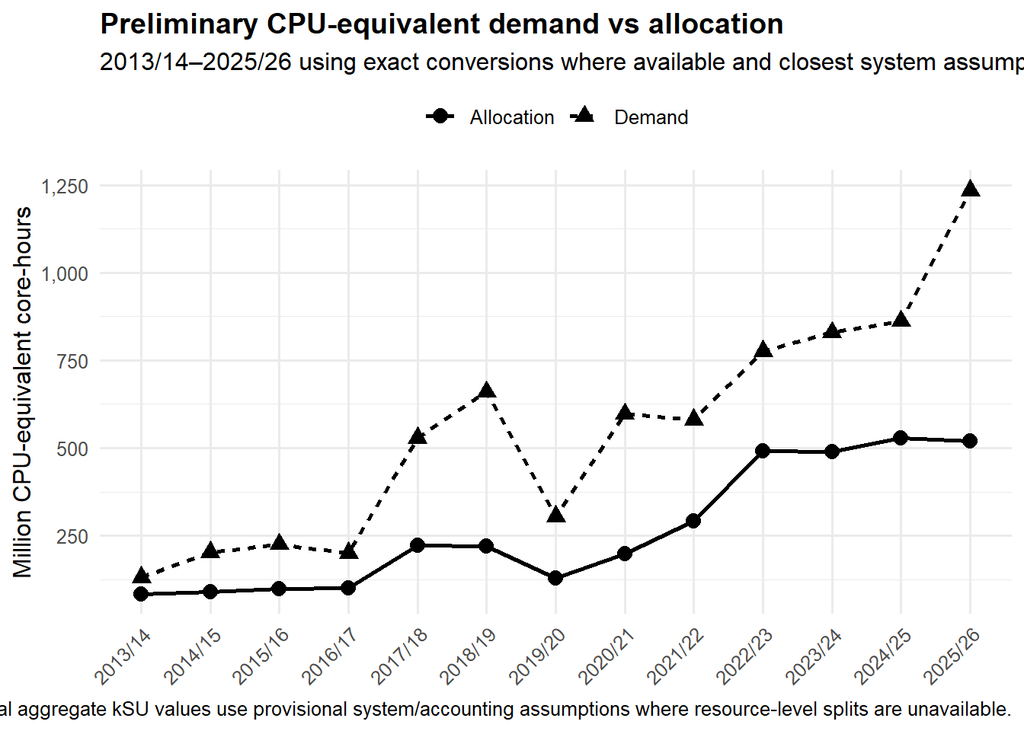

```r
cpu_chart <- cpu_equivalent %>%
  select(
    period,
    demand_cpu_equiv_hours,
    allocation_cpu_equiv_hours
  ) %>%
  pivot_longer(
    cols = c(
      demand_cpu_equiv_hours,
      allocation_cpu_equiv_hours
    ),
    names_to = "measure",
    values_to = "cpu_equiv_hours"
  ) %>%
  mutate(
    measure = recode(
      measure,
      demand_cpu_equiv_hours = "Demand",
      allocation_cpu_equiv_hours = "Allocation"
    ),
    period = factor(
      period,
      levels = all_periods,
      ordered = TRUE
    ),
    million_cpu_equiv_hours = cpu_equiv_hours / 1e6
  )

ggplot(
  cpu_chart,
  aes(
    x = period,
    y = million_cpu_equiv_hours,
    group = measure,
    linetype = measure,
    shape = measure
  )
) +
  geom_line(linewidth = 0.9) +
  geom_point(size = 3.2) +
  scale_x_discrete(drop = FALSE) +
  scale_y_continuous(labels = label_number(big.mark = ",")) +
  labs(
    title = "Preliminary CPU-equivalent demand vs allocation",
    subtitle = "2013/14–2025/26 using exact conversions where available and closest system assumptions elsewhere",
    x = NULL,
    y = "Million CPU-equivalent core-hours",
    linetype = NULL,
    shape = NULL,
    caption = paste(
      "Draft for discussion only.",
      "Historical aggregate kSU values use provisional system/accounting assumptions where resource-level splits are unavailable."
    )
  ) +
  theme_minimal(base_size = 12) +
  theme(
    legend.position = "top",
    plot.title = element_text(face = "bold"),
    axis.text.x = element_text(
      angle = 45,
      hjust = 1
    )
  )
```

## Preliminary gap and fulfilment rate

These are also **working estimates**, because they inherit the conversion assumptions above.

```r
cpu_gap <- cpu_equivalent %>%
  mutate(
    gap_cpu_equiv_hours =
      demand_cpu_equiv_hours - allocation_cpu_equiv_hours,

    fulfilment_rate =
      allocation_cpu_equiv_hours / demand_cpu_equiv_hours
  ) %>%
  transmute(
    period,
    demand_million = demand_cpu_equiv_hours / 1e6,
    allocation_million = allocation_cpu_equiv_hours / 1e6,
    gap_million = gap_cpu_equiv_hours / 1e6,
    fulfilment_rate = percent(fulfilment_rate, accuracy = 0.1),
    confidence
  )

cpu_gap %>% kable(digits = 1)
```

| period | demand_million | allocation_million | gap_million | fulfilment_rate | confidence |
| --- | --- | --- | --- | --- | --- |
| 2013/14 | 131.4 | 83.5 | 47.9 | 63.6% | Lower |
| 2014/15 | 202.5 | 88.7 | 113.8 | 43.8% | Medium |
| 2015/16 | 225.0 | 97.1 | 127.9 | 43.2% | Medium |
| 2016/17 | 200.0 | 100.0 | 100.0 | 50.0% | Higher |
| 2017/18 | 528.6 | 222.0 | 306.6 | 42.0% | Higher |
| 2018/19 | 660.0 | 220.0 | 440.0 | 33.3% | Higher |
| 2019/20 | 304.0 | 127.6 | 176.4 | 42.0% | Lower |
| 2020/21 | 596.9 | 199.0 | 397.9 | 33.3% | Lower |
| 2021/22 | 581.1 | 290.6 | 290.6 | 50.0% | Lower |
| 2022/23 | 775.5 | 491.5 | 284.0 | 63.4% | Higher |
| 2023/24 | 829.2 | 488.2 | 340.9 | 58.9% | Lower |
| 2024/25 | 861.6 | 527.5 | 334.0 | 61.2% | Medium |
| 2025/26 | 1235.0 | 518.6 | 716.4 | 42.0% | Higher |

## Chart 2 — Preliminary GPU demand vs allocation

The GPU chart keeps **all financial years on the x-axis**.

However, I do **not** force a GPU estimate for years where there is no defensible GPU share.  
For those years the value remains `NA`, because treating missing GPU information as zero would be misleading.

Current GPU logic:

- **2013/14:** Fornax GPU is identified, but neither the GPU kSU split nor the historical conversion factor is confirmed → `NA`
- **2014/15–2020/21:** no defensible GPU split in the current annual data → `NA`
- **2021/22:** use the observed **2022/23 GPU share** as a working proxy
- **2022/23:** exact Setonix GPU split
- **2023/24:** use the observed **2022/23 GPU share** as the nearest-year proxy
- **2024/25:** allocation uses the exact Setonix GPU split; demand uses the **2025/26 demand GPU share**
- **2025/26:** exact Setonix GPU split

```r
# Observed GPU shares from years with known resource splits
gpu_share_2022_demand <- 172341 / 1333240
gpu_share_2022_allocation <- 162400 / 817956

gpu_share_2025_demand <- 384420 / 2242817
gpu_share_2025_allocation <- 160000 / 872288

gpu_equivalent <- demand_raw %>%
  mutate(
    demand_gpu_ksu = case_when(
      period == "2021/22" ~ demand * gpu_share_2022_demand,
      period == "2022/23" ~ 172341,
      period == "2023/24" ~ demand * gpu_share_2022_demand,
      period == "2024/25" ~ demand * gpu_share_2025_demand,
      period == "2025/26" ~ 384420,
      TRUE ~ NA_real_
    ),

    allocation_gpu_ksu = case_when(
      period == "2021/22" ~ allocation * gpu_share_2022_allocation,
      period == "2022/23" ~ 162400,
      period == "2023/24" ~ allocation * gpu_share_2022_allocation,
      period == "2024/25" ~ 171050,
      period == "2025/26" ~ 160000,
      TRUE ~ NA_real_
    ),

    # Setonix GPU accounting rule
    demand_gpu_hours = demand_gpu_ksu * 1000 / 128,
    allocation_gpu_hours = allocation_gpu_ksu * 1000 / 128,

    gpu_assumption = case_when(
      period %in% c("2022/23", "2025/26") ~
        "Exact resource split",
      period == "2024/25" ~
        "Allocation exact; demand uses 2025/26 GPU share",
      period %in% c("2021/22", "2023/24") ~
        "Uses 2022/23 GPU share as proxy",
      TRUE ~
        "No defensible GPU estimate from current data"
    )
  )
```

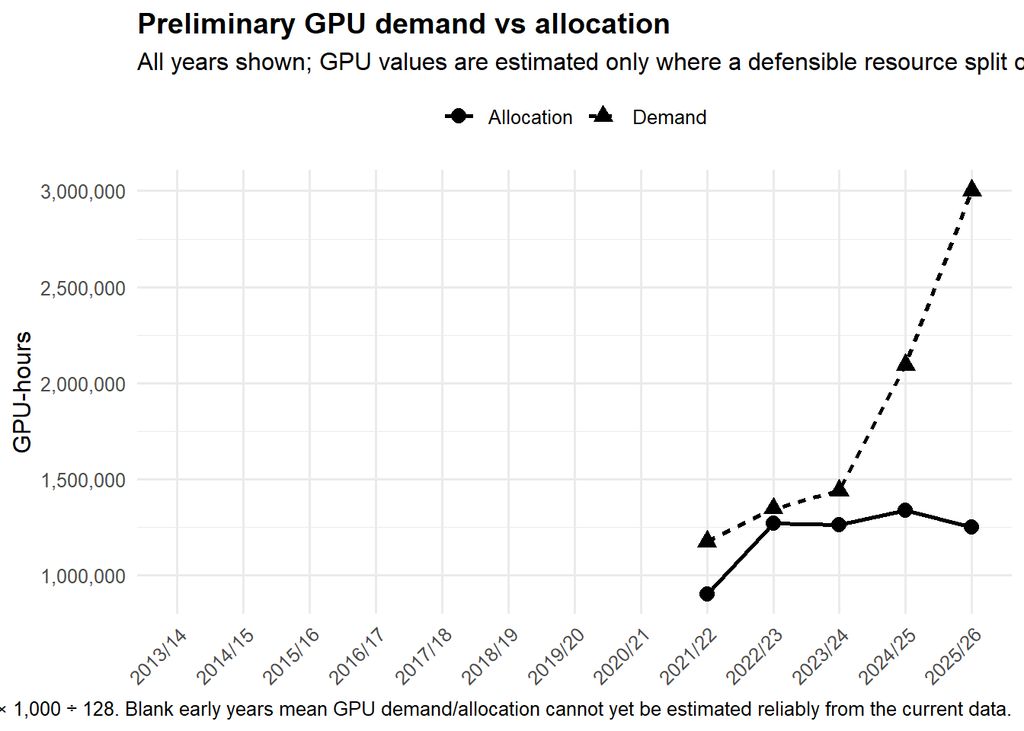

```r
gpu_chart <- gpu_equivalent %>%
  select(
    period,
    demand_gpu_hours,
    allocation_gpu_hours
  ) %>%
  pivot_longer(
    cols = c(
      demand_gpu_hours,
      allocation_gpu_hours
    ),
    names_to = "measure",
    values_to = "gpu_hours"
  ) %>%
  mutate(
    measure = recode(
      measure,
      demand_gpu_hours = "Demand",
      allocation_gpu_hours = "Allocation"
    ),
    period = factor(
      period,
      levels = all_periods,
      ordered = TRUE
    )
  )

ggplot(
  gpu_chart,
  aes(
    x = period,
    y = gpu_hours,
    group = measure,
    linetype = measure,
    shape = measure
  )
) +
  geom_line(linewidth = 0.9, na.rm = FALSE) +
  geom_point(size = 3.2, na.rm = TRUE) +
  scale_x_discrete(drop = FALSE) +
  scale_y_continuous(labels = label_number(big.mark = ",")) +
  labs(
    title = "Preliminary GPU demand vs allocation",
    subtitle = "All years shown; GPU values are estimated only where a defensible resource split or proxy is available",
    x = NULL,
    y = "GPU-hours",
    linetype = NULL,
    shape = NULL,
    caption = paste(
      "Setonix GPU conversion: kSU × 1,000 ÷ 128.",
      "Blank early years mean GPU demand/allocation cannot yet be estimated reliably from the current data."
    )
  ) +
  theme_minimal(base_size = 12) +
  theme(
    legend.position = "top",
    plot.title = element_text(face = "bold"),
    axis.text.x = element_text(
      angle = 45,
      hjust = 1
    )
  )
```

## Chart 3 — kSU-equivalent demand vs allocation

This chart puts **every year into a kSU-equivalent scale**.

For years already reported in kSU, I keep the original values.  
For years reported in million hours/core-hours, I reverse the historical CPU conversion:

`kSU-equivalent = hours ÷ 1,000`

This is a **comparison scale**, not a claim that those years were originally reported in kSU.

```r
ksu_equivalent <- demand_raw %>%
  mutate(
    demand_ksu_equiv = case_when(
      demand_uom == "kSU" ~ demand,

      demand_uom %in% c(
        "million hours",
        "million core-hours",
        "million CPU-hours"
      ) ~ demand * 1e6 / 1000,

      TRUE ~ NA_real_
    ),

    allocation_ksu_equiv = case_when(
      allocation_uom == "kSU" ~ allocation,

      allocation_uom %in% c(
        "million hours",
        "million core-hours",
        "million CPU-hours"
      ) ~ allocation * 1e6 / 1000,

      TRUE ~ NA_real_
    ),

    ksu_basis = case_when(
      demand_uom == "kSU" & allocation_uom == "kSU" ~
        "Original values already in kSU",

      TRUE ~
        "Hours reverse-converted to kSU-equivalent using 1 kSU = 1,000 CPU-equivalent hours"
    )
  )
```

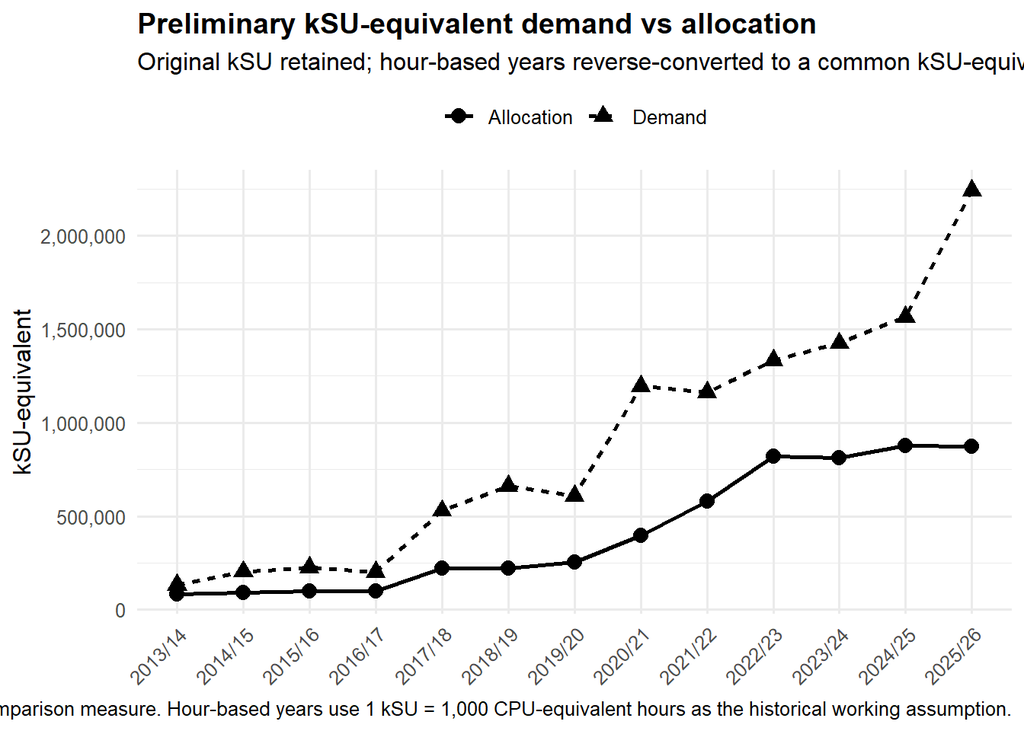

```r
ksu_chart <- ksu_equivalent %>%
  select(
    period,
    demand_ksu_equiv,
    allocation_ksu_equiv
  ) %>%
  pivot_longer(
    cols = c(
      demand_ksu_equiv,
      allocation_ksu_equiv
    ),
    names_to = "measure",
    values_to = "ksu_equiv"
  ) %>%
  mutate(
    measure = recode(
      measure,
      demand_ksu_equiv = "Demand",
      allocation_ksu_equiv = "Allocation"
    ),
    period = factor(
      period,
      levels = all_periods,
      ordered = TRUE
    )
  )

ggplot(
  ksu_chart,
  aes(
    x = period,
    y = ksu_equiv,
    group = measure,
    linetype = measure,
    shape = measure
  )
) +
  geom_line(linewidth = 0.9) +
  geom_point(size = 3.2) +
  scale_x_discrete(drop = FALSE) +
  scale_y_continuous(labels = label_number(big.mark = ",")) +
  labs(
    title = "Preliminary kSU-equivalent demand vs allocation",
    subtitle = "Original kSU retained; hour-based years reverse-converted to a common kSU-equivalent comparison scale",
    x = NULL,
    y = "kSU-equivalent",
    linetype = NULL,
    shape = NULL,
    caption = paste(
      "Draft comparison measure.",
      "Hour-based years use 1 kSU = 1,000 CPU-equivalent hours as the historical working assumption."
    )
  ) +
  theme_minimal(base_size = 12) +
  theme(
    legend.position = "top",
    plot.title = element_text(face = "bold"),
    axis.text.x = element_text(
      angle = 45,
      hjust = 1
    )
  )
```

## Assumption summary for discussion

```r
cpu_equivalent %>%
  select(
    period,
    assumption,
    confidence,
    reason
  ) %>%
  kable()
```

| period | assumption | confidence | reason |
| --- | --- | --- | --- |
| 2013/14 | Historical CPU-equivalent assumption: aggregate kSU × 1,000 | Lower | Demand is directly reported as 131,356 kSU in NCI Annual Report 2013/14, Table 3. Allocation is directly reported as 83,505 kSU in Table 2. |
| 2014/15 | Demand reported in hours; allocation uses historical CPU kSU conversion | Medium | Demand is derived from NCI Annual Report 2014/15: 75 million hours available × 2.7 demand/supply = 202.5 million hours. Allocation is directly reported as 88,731 kSU in Table 3. Need confirmation on h… |
| 2015/16 | Demand reported in hours; allocation uses historical CPU kSU conversion | Medium | Demand is derived from NCI Annual Report 2015/16: 75 million hours available ÷ one-third fulfilment = 225 million hours. Allocation is directly reported as 97,112 kSU in Table 2. Need confirmation on … |
| 2016/17 | Reported directly in hours/core-hours | Higher | Pawsey Annual Report 2016/17 states more than 200 million core-hours were requested; 200 million is used as a conservative demand proxy. The report states 100 million core-hours were made available, u… |
| 2017/18 | Reported directly in hours/core-hours | Higher | NCI NCMAS allocation outcome reports 222 million hours allocated, representing 42% of requested compute. Demand is therefore derived as 222 ÷ 0.42 = 528.57 million hours. Need confirmation that these … |
| 2018/19 | Reported directly in hours/core-hours | Higher | NCMAS 2020 Information for Applicants reports about 220 million CPU-hours available and demand at roughly three times supply. Demand is therefore estimated as about 660 million CPU-hours. Both values … |
| 2019/20 | Aggregate kSU treated as Gadi-equivalent: kSU × 1,000 ÷ 2 | Lower | NCI 2019/20 Compute Allocations Detail directly reports 255,148 kSU allocated. Demand is a conservative proxy using the minimum available capacity of 303,990 kSU × 2, based on the reported 2–3× demand… |
| 2020/21 | Aggregate kSU treated as Gadi-equivalent: kSU × 1,000 ÷ 2 | Lower | Official NCMAS allocation data reports 397,937 kSU allocated. Demand is derived as 397,937 × 3 = 1,193,811 kSU using a retrospective statement that allocation was about one-third of requested compute. |
| 2021/22 | Aggregate kSU treated as Gadi-equivalent: kSU × 1,000 ÷ 2 | Lower | Official NCMAS 2022 outcomes report 581,115 kSU allocated. NCMAS 2023 Information for Applicants reports about 50% fulfilment, so demand is derived as 581,115 ÷ 0.50 = 1,162,230 kSU. |
| 2022/23 | Exact conversion from known Gadi / Setonix resource split | Higher | NCMAS 2026 Outcomes retrospectively reports requests of Gadi 770,866 + Setonix CPU 390,033 + Setonix GPU 172,341 = 1,333,240 kSU. Allocation is directly summed as 328,156 + 327,400 + 162,400 = 817,956… |
| 2023/24 | Approximation using observed 2022/23 blended CPU-equivalent ratio | Lower | NCMAS 2025 Information for Applicants reports a 57% fulfilment rate and 812,569 kSU allocated. Demand is therefore derived as 812,569 ÷ 0.57 = 1,425,559.65 kSU. |
| 2024/25 | Demand uses 2025/26 blended ratio; allocation uses known resource split | Medium | NCMAS 2026 Information for Applicants reports a 56% fulfilment rate and 876,200 kSU allocated. Demand is therefore derived as 876,200 ÷ 0.56 = 1,564,642.86 kSU. |
| 2025/26 | Exact conversion from known Gadi / Setonix resource split | Higher | NCMAS 2026 Outcomes directly reports requests of Gadi 1,246,722 + Setonix CPU 611,675 + Setonix GPU 384,420 = 2,242,817 kSU. Comparable allocation is 387,288 + 325,000 + 160,000 = 872,288 kSU; Setonix… |

## Questions to validate with NCI / Pawsey

1. **Historical values:** Are the demand and allocation figures interpreted correctly, particularly the years where demand was derived from fulfilment rates or capacity statements?
2. **Older systems:** Is it reasonable to use the Raijin/Magnus CPU rule as a CPU-equivalent approximation for the early aggregate kSU years, and how material was Fornax GPU in those totals?
3. **2019/20–2021/22:** Is treating aggregate kSU as Gadi-equivalent (`kSU × 1,000 ÷ 2`) a reasonable working approximation for these transition years?
4. **Recent aggregate years:** If the requested resource split is unavailable, is using the nearest observed Gadi/Setonix resource mix a reasonable approximation for a national trend?
5. **Accounting changes:** Did the definition of an SU / kSU or the charging/accounting method change across systems or over time in a way that would materially change these comparisons?
6. **CPU and GPU:** Is it appropriate to keep CPU-equivalent core-hours and GPU-hours as separate measures rather than combining them?
7. **Definition of demand:** Is requested compute the most appropriate measure of researcher demand, or would another metric be preferable?

## Meeting note

The CPU chart is deliberately a **CPU-equivalent working series** rather than a claim that every historical value represents observed CPU core-hours.

The hierarchy used is:

1. exact resource-level conversion where available;
2. directly reported CPU/core-hours where available;
3. closest system-specific conversion where the dominant historical system is known;
4. nearest observed resource mix for recent years where only an aggregate kSU total is available.

This provides a complete trend for discussion while keeping the assumptions explicit and easy to replace after validation.